# 1.Imports and Preprocessing

# 3. Data Filtering and Feature Engineering

## 3.1 Data Filtering

```
Total number of rows: 622646
Number of rows within Tallinn: 618824
Number of rows outside of Tallinn: 3822
```

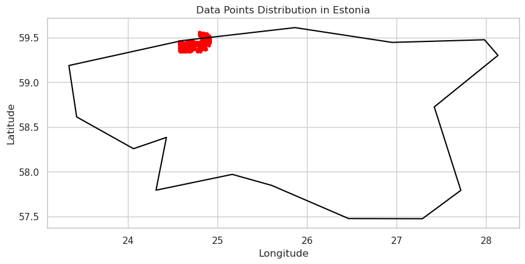

```python
# Filter the DataFrame to include only points within Tallinn
df_tallinn = df_cleaned[
    (df_cleaned['start_lat'] >= lat_min) & (df_cleaned['start_lat'] <= lat_max) &
    (df_cleaned['start_lng'] >= lng_min) & (df_cleaned['start_lng'] <= lng_max)
]

# Count the number of rows in the original DataFrame
original_row_count = df_cleaned.shape[0]

# Count the number of rows in the filtered DataFrame
tallinn_row_count = df_tallinn.shape[0]

# Calculate the number of rows outside of Tallinn
outside_tallinn_count = original_row_count - tallinn_row_count

# Print the results
print(f"Total number of rows: {original_row_count}")
print(f"Number of rows within Tallinn: {tallinn_row_count}")
print(f"Number of rows outside of Tallinn: {outside_tallinn_count}")

# Load the shapefile for countries
world = gpd.read_file('data/ne_110m_admin_0_countries.shp')

# Filter to get only Estonia
estonia = world[world.SOVEREIGNT == 'Estonia']

# Create a GeoDataFrame from your latitude and longitude
geometry = gpd.points_from_xy(df_tallinn['start_lng'], df_tallinn['start_lat'])
gdf_points = gpd.GeoDataFrame(df_tallinn, geometry=geometry)

# Plot the map
fig, ax = plt.subplots(figsize=(10, 10))
estonia.boundary.plot(ax=ax, color='black')
gdf_points.plot(ax=ax, color='red', markersize=5, alpha=0.5)

plt.title('Data Points Distribution in Estonia')
plt.xlabel('Longitude')
plt.ylabel('Latitude')
plt.show()
```

## 3.2 Outlier treatment

### Reasons for Choosing Percentile-Based Capping

```python
# Calculate the 2nd and 98th percentiles
percentile_2 = df_tallinn['ride_value'].quantile(0.02)
percentile_98 = df_tallinn['ride_value'].quantile(0.98)

# Count rows below the 2nd percentile
rows_below_2 = df_tallinn[df_tallinn['ride_value'] < percentile_2].shape[0]

# Count rows above the 98th percentile
rows_above_98 = df_tallinn[df_tallinn['ride_value'] > percentile_98].shape[0]

# Print the results
print(f"2nd Percentile: {percentile_2}")
print(f"Number of rows below 2nd percentile: {rows_below_2}")
print(f"98th Percentile: {percentile_98}")
print(f"Number of rows above 98th percentile: {rows_above_98}")

# Filter the DataFrame
df_tallinn_filtered = df_tallinn[(df_tallinn['ride_value'] >= percentile_2) & (df_tallinn['ride_value'] <= percentile_98)]
```

```
2nd Percentile: 0.125
Number of rows below 2nd percentile: 1409
98th Percentile: 3.7035
Number of rows above 98th percentile: 12376
```

## 3.3 Location Clustering

### Why Choose MiniBatchKMeans

MiniBatchKMeans is often chosen for its efficiency and speed when dealing with large datasets. It works on small random batches of the data, significantly reducing the computational burden compared to standard K-Means.

Its implementation also tends to require less fine-tuning of hyperparameters compared to other clustering methods, which can simplify the clustering process in practical applications.

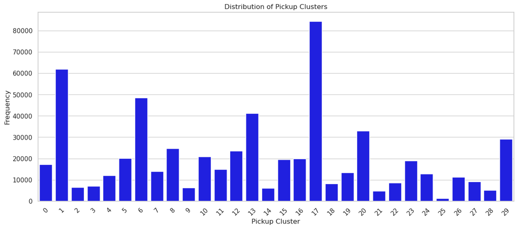

```python
# Clustering pickups
coord = df_tallinn_filtered[["start_lat", "start_lng"]].values
regions = MiniBatchKMeans(n_clusters=30, batch_size=10000, init='k-means++', n_init=10, random_state=42).fit(coord)

# Predict cluster assignments
cluster_column = regions.predict(df_tallinn_filtered[["start_lat", "start_lng"]])
df_tallinn_filtered["pickup_cluster"] = cluster_column

# Step 1: Pre-compute the counts for each cluster
pickup_cluster_counts = df_tallinn_filtered['pickup_cluster'].value_counts().sort_index()

# Step 2: Plot distribution of pickup clusters
plt.figure(figsize=(15, 6))
sns.barplot(x=pickup_cluster_counts.index, y=pickup_cluster_counts.values, color='blue')
plt.title('Distribution of Pickup Clusters')
plt.xlabel('Pickup Cluster')
plt.ylabel('Frequency')
plt.xticks(rotation=45)  # Rotate x-axis labels for better readability
plt.show()
```

### Visualizing clusters

```python
# Group by the 'cluster' column and calculate min and max for latitude and longitude
cluster_bounds = df_tallinn_filtered.groupby('pickup_cluster').agg(
    min_latitude=('start_lat', 'min'),
    max_latitude=('start_lat', 'max'),
    min_longitude=('start_lng', 'min'),
    max_longitude=('start_lng', 'max'),
    ride_count=('pickup_cluster', 'count')  # Adding count of rides per cluster
).reset_index()

# save cluset bounderies
cluster_bounds[["pickup_cluster","min_latitude","max_latitude","min_longitude","max_longitude"]].to_csv("data/cluster_bounds.csv", index = False)

# Calculate percentiles
percentiles = cluster_bounds['ride_count'].quantile([0.0, 0.167, 0.33, 0.5, 0.667, 0.833, 1.0]).tolist()

# Function to assign colors based on ride_count percentiles with a specific exception
def get_color(ride_count):
    if ride_count < percentiles[1]:  # 0-16.7 percentile
        return 'lightblue'
    elif ride_count < percentiles[2]:  # 16.7-33.3 percentile
        return 'blue'
    elif ride_count < percentiles[3]:  # 33.3-50 percentile
        return 'lightgreen'
    elif ride_count < percentiles[4]:  # 50-66.7 percentile
        return 'green'
    elif ride_count < percentiles[5]:  # 66.7-83.3 percentile
        return 'orange'
    else:  # 83.3-100 percentile
        return 'red'

# Add a column to cluster_bounds with the color based on ride_count
cluster_bounds['cluster_color'] = cluster_bounds['ride_count'].apply(get_color)

# Create a Folium map centered at an average location
m = folium.Map(location=[59.4300, 24.7000], zoom_start=11)

# Add pickup cluster markers to the map
for i in range(len(cluster_bounds['pickup_cluster'])):
    # Calculate the average latitude and longitude for the cluster
    avg_lat = (cluster_bounds['min_latitude'][i] + cluster_bounds['max_latitude'][i]) / 2
    avg_lng = (cluster_bounds['min_longitude'][i] + cluster_bounds['max_longitude'][i]) / 2

    # Add a marker for each pickup cluster with color based on ride_count
    folium.Marker(
        location=[avg_lat, avg_lng],
        popup=(f'Pickup Cluster: {cluster_bounds["pickup_cluster"][i]}<br>'
               f'Ride Count: {cluster_bounds["ride_count"][i]}'),
        icon=folium.Icon(color=cluster_bounds["cluster_color"][i])
    ).add_to(m)

# Save the map to an HTML fileí
m.save("pickup_clusters_map.html")

# Display the map
m
```

Make this Notebook Trusted to load map: File -> Trust Notebook

[interactive chart not shown]

## 3.4 Aggregation on clusters

```python
df_agg = df_tallinn_filtered.copy()

# 'year','month','day_of_month','monthly_quarter' could be kept if dataset contains more diverse data
columns_to_drop = ['start_time','start_lat','start_lng','end_lat', 'end_lng','pickup_time','ride_value_bins']

# Drop columns
df_agg = df_agg.drop(columns=columns_to_drop)

# Aggregate demand count and sum of ride values in one go
df_agg = df_agg.groupby(['pickup_cluster', 'year', 'month', 'monthly_quarter',
                                   'day_of_month', 'weekday', 'hour', 'hourly_segments']).agg(
    demand_count=('ride_value', 'size'),           # Count of rows for demand
    value_sum=('ride_value', 'sum')         # Sum of ride_value
).reset_index()

df_agg.head()
```

|  | pickup_cluster | year | month | monthly_quarter | day_of_month | weekday | hour | hourly_segments | demand_count | value_sum |
| --- | --- | --- | --- | --- | --- | --- | --- | --- | --- | --- |
| 0 | 0 | 2022 | 3 | Q1 | 1 | 1 | 0 | H1 | 11 | 13.83850 |
| 1 | 0 | 2022 | 3 | Q1 | 1 | 1 | 1 | H1 | 4 | 2.74500 |
| 2 | 0 | 2022 | 3 | Q1 | 1 | 1 | 2 | H1 | 4 | 4.03775 |
| 3 | 0 | 2022 | 3 | Q1 | 1 | 1 | 3 | H1 | 7 | 6.33650 |
| 4 | 0 | 2022 | 3 | Q1 | 1 | 1 | 4 | H2 | 14 | 12.77900 |

## 3.5 Create average rider value tables

##### We will use it for the final solution to calculate roughly an expected monetary benefit

```python
rider_value_data = df_tallinn_filtered[["pickup_cluster","day_of_month","weekday","hour","ride_value"]]
# Group by the relevant columns and calculate the required statistics
rider_value_data = rider_value_data.groupby(['pickup_cluster', 'day_of_month', 'weekday', 'hour']).ride_value.agg(
                                            avg_ride_value='mean',
                                            p25_ride_value=lambda x: x.quantile(0.25),
                                            p75_ride_value=lambda x: x.quantile(0.75)
                                        ).reset_index()

rider_value_data.to_csv("data/rider_value_data.csv", index = False)
```